# Final Project DS 805: Statistical Learning

Tyler Merrick,Aleena Linson

## Data Requirements:

- You can pick any data you want as long as it is a classification problem.
- The data source used is:
  - Kaggle https://www.kaggle.com/yasserh/titanic-dataset
- Variables in this data set include: PassengerId - Passenger ID Survived - Weather Survived or not: 0 = No, 1 = Yes Pclass - Ticket class: 1 = 1st, 2 = 2nd, 3 = 3rd Name - Name of the Passenger Gender - male or female Age - Age in Years SibSp - No. of siblings / spouses aboard the Titanic Parch - No. of parents / children aboard the Titanic Ticket - Ticket number Fare - Passenger fare Embarked - Port of Embarkation:C = Cherbourg, Q = Queenstown, S = Southampton
- Read your data in R and call it df. For the rest of this document `y` refers to the variable you are predicting.
- Predicting the variable “Survived”

Below is the snapshot of the dataset:

```r
titanic=read.table("/Users/aleena/Desktop/MSBA/DS805/project/Titanic-Dataset.csv", header = TRUE, sep=",", dec=".")
attach(titanic)
titanic=titanic[,-8]
head(titanic)
```

```
##   PassengerId Survived Pclass    Sex Age SibSp Parch  Fare Embarked
## 1           1        0      3   male  22     1     0  7.25        S
## 2           2        1      1 female  38     1     0 71.28        C
## 3           3        1      3 female  26     0     0  7.93        S
## 4           4        1      1 female  35     1     0 53.10        S
## 5           5        0      3   male  35     0     0  8.05        S
## 6           6        0      3   male  NA     0     0  8.46        Q
```

## The grading rubric can be found below:

|  | R code | Decision/Why | Communication of findings |
| --- | --- | --- | --- |
| Percentage of Assigned Points | 30% | 35% | 35% |

- **Decision/why?**: Explain your reasoning behind your choice of the procedure, set of variables and such for the question.
  - Explain why you use the procedure/model/variable
  - To exceed this criterion, describe steps taken to implement the procedure in a non technical way.
- **Communication of your findings**: Explain your results in terms of training MSE, testing MSE, and prediction of the variable `Y`
  - Explain why you think one model is better than the other.
  - To exceed this criterion, explain your model and how it predicts `y` in a non technical way.

## Part 1: Exploratory Data Analysis (20 points)

1. Check for existence of NA’s (missing data)

```r
titanic[titanic$Embarked == "","Embarked"] <- "S"
table(titanic$Embarked)
```

```
##
##   C   Q   S
## 168  77 646
```

```r
titanic=na.omit(titanic)
head(titanic)
```

```
##   PassengerId Survived Pclass    Sex Age SibSp Parch  Fare Embarked
## 1           1        0      3   male  22     1     0  7.25        S
## 2           2        1      1 female  38     1     0 71.28        C
## 3           3        1      3 female  26     0     0  7.93        S
## 4           4        1      1 female  35     1     0 53.10        S
## 5           5        0      3   male  35     0     0  8.05        S
## 7           7        0      1   male  54     0     0 51.86        S
```

survived~ pclass+Sex+Age+SipSp+PArch+Fare+Embarked

2. If necessary, classify all categorical variables **except the one you are predicting** as factors. Calculate the summary statistics of the entire data set.

```r
titanic$Pclass<-as.factor(titanic$Pclass)
titanic$Sex<-as.factor(titanic$Sex)
titanic$Embarked<-as.factor(titanic$Embarked)
titanic$Survived<- as.factor((titanic$Survived))
str(titanic)
```

```
## 'data.frame':    714 obs. of  9 variables:
##  $ PassengerId: int  1 2 3 4 5 7 8 9 10 11 ...
##  $ Survived   : Factor w/ 2 levels "0","1": 1 2 2 2 1 1 1 2 2 2 ...
##  $ Pclass     : Factor w/ 3 levels "1","2","3": 3 1 3 1 3 1 3 3 2 3 ...
##  $ Sex        : Factor w/ 2 levels "female","male": 2 1 1 1 2 2 2 1 1 1 ...
##  $ Age        : int  22 38 26 35 35 54 2 27 14 4 ...
##  $ SibSp      : int  1 1 0 1 0 0 3 0 1 1 ...
##  $ Parch      : int  0 0 0 0 0 0 1 2 0 1 ...
##  $ Fare       : num  7.25 71.28 7.93 53.1 8.05 ...
##  $ Embarked   : Factor w/ 3 levels "C","Q","S": 3 1 3 3 3 3 3 3 1 3 ...
##  - attr(*, "na.action")= 'omit' Named int [1:177] 6 18 20 27 29 30 32 33 37 43 ...
##   ..- attr(*, "names")= chr [1:177] "6" "18" "20" "27" ...
```

3. For the numerical variables, plot box plots based on values of `Survived`. Do you see a difference between the box plots for any of the variables you choose?

This variable represents the number of sibings and spouse aboard the Titanc. These two plots look identical, the only main difference is the outliers.

The Parch corresponds to the number of parents or children aboard the Titanic. The mean value is identical for both categories. The spread is a bit different, Q3 is much higher for people that survived. It’s a bit suprising but maybe these people had priority over people that had none to jump into the rescue boats.

This variable corresponds to the price people paid their tickets. The mean and Q3 is higher for people that survived. It seems like the price of the ticket was a variable of importance as well.

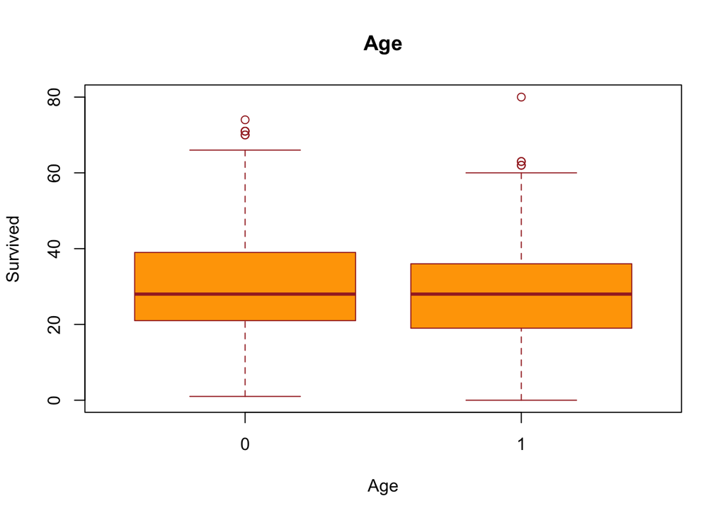

```r
boxplot (Age~Survived,main = "Age",xlab = "Age",ylab = "Survived",col = "orange",border = "brown",horizontal = FALSE)
```

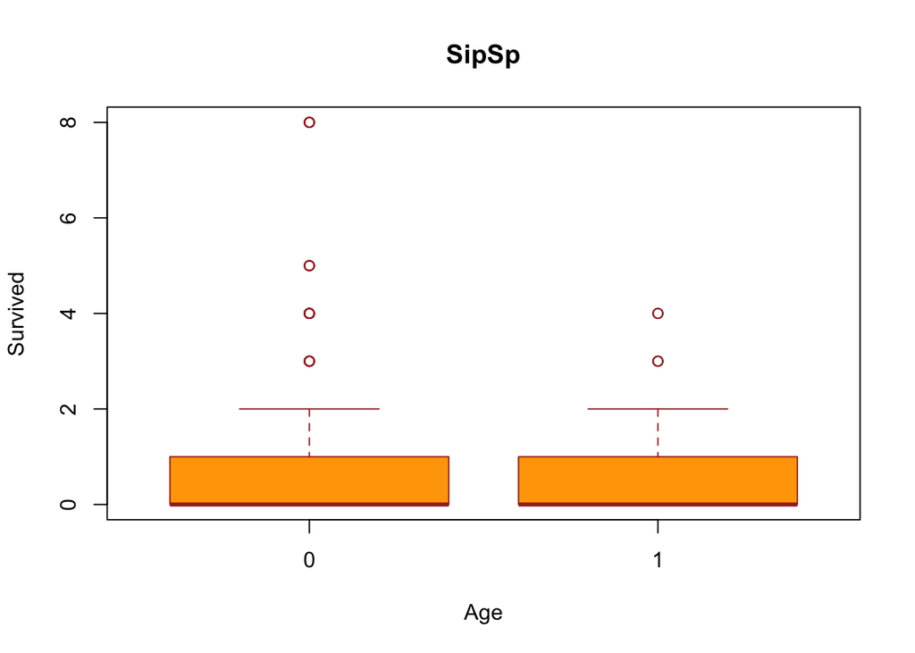

```r
boxplot (SibSp~Survived,main = "SipSp",xlab = "Age",ylab = "Survived",col = "orange",border = "brown",horizontal = FALSE)
```

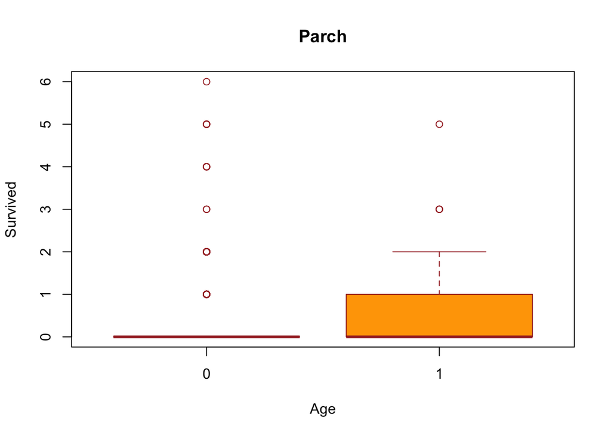

```r
boxplot (Parch~Survived,main = "Parch",xlab = "Age",ylab = "Survived",col = "orange",border = "brown",horizontal = FALSE)
```

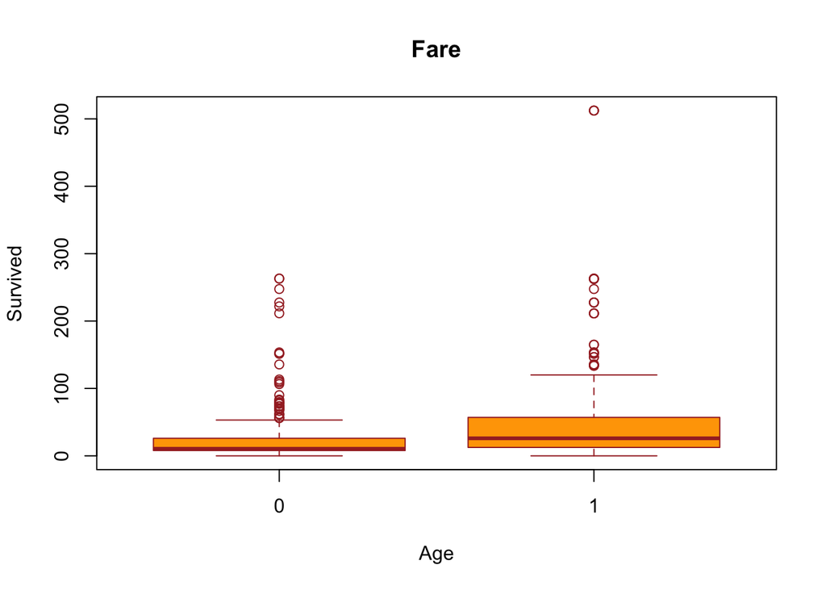

```r
boxplot (Fare~Survived,main = "Fare",xlab = "Age",ylab = "Survived",col = "orange",border = "brown",horizontal = FALSE)
```

4. For the categorical variables, plot bar charts for the different values of `y`. Do you see a difference between plots for any of the variables you choose?

For the categorical variables, plot bar charts

[figure not shown]

```r
# Grouped Bar Plot
counts <- table(titanic$Pclass,titanic$Survived)
barplot(counts, main="Survival based on Gender",
  xlab="Number of Male and female", col=c("light blue","light pink"),
  legend = rownames(counts), beside=TRUE)
```

[figure not shown]

```r
counts <- table(titanic$Embarked,titanic$Survived)
barplot(counts, main="Survival based on Gender",
  xlab="Number of Male and female", col=c("light blue","light pink","red","yellow"),
  legend = rownames(counts), beside=TRUE)
```

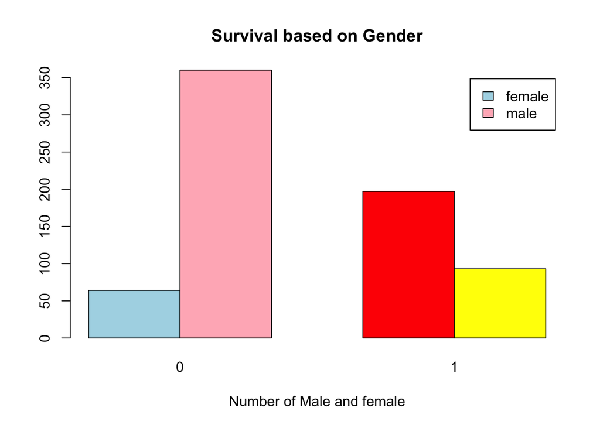

```r
counts <- table(titanic$Sex,titanic$Survived)
barplot(counts, main="Survival based on Gender",
  xlab="Number of Male and female", col=c("light blue","light pink","red","yellow"),
  legend = rownames(counts), beside=TRUE)
```

6. Test/training separation: Separate your data into 80% training and 20% testing data. Do not forget to set seed. Please use the same separation for the whole assignment, as it is needed to be able to compare the models.

```r
set.seed(1)
n=round(nrow(titanic)*.8)
training=sample(nrow(titanic), n)
train=titanic[training,]
test=titanic[-training,]
```

## Part 2: Logistic Regression or LDA (15 points)

1. Develop a classification model where the variable `y` is the dependent variable using the Logistic Regression or LDA, rest of the variables, and your training data set.

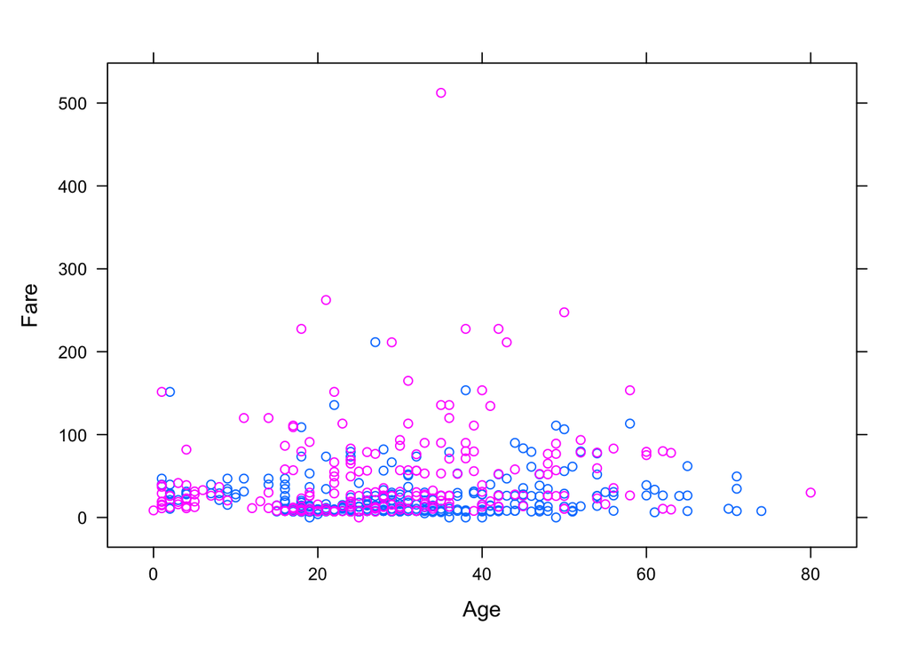

```r
xyplot(train$Fare~train$Age, groups=train$Survived, ylab="Fare", xlab="Age")
```

```r
logfit<-glm(Survived~., data=train, family=binomial)
summary(logfit)
```

```
##
## Call:
## glm(formula = Survived ~ ., family = binomial, data = train)
##
## Deviance Residuals:
##     Min       1Q   Median       3Q      Max
## -2.6658  -0.6070  -0.3415   0.5352   2.4227
##
## Coefficients:
##               Estimate Std. Error z value Pr(>|z|)
## (Intercept)  4.6354311  0.7009534   6.613 3.77e-11 ***
## PassengerId  0.0003476  0.0004514   0.770  0.44135
## Pclass2     -1.1694788  0.4014726  -2.913  0.00358 **
## Pclass3     -2.5477697  0.4327914  -5.887 3.94e-09 ***
## Sexmale     -2.8940265  0.2626613 -11.018  < 2e-16 ***
## Age         -0.0430490  0.0093800  -4.589 4.44e-06 ***
## SibSp       -0.3897331  0.1585923  -2.457  0.01399 *
## Parch       -0.0748286  0.1461970  -0.512  0.60877
## Fare        -0.0003839  0.0045859  -0.084  0.93329
## EmbarkedQ   -0.7493360  0.6513308  -1.150  0.24995
## EmbarkedS   -0.5312653  0.3089003  -1.720  0.08546 .
## ---
## Signif. codes:  0 '***' 0.001 '**' 0.01 '*' 0.05 '.' 0.1 ' ' 1
##
## (Dispersion parameter for binomial family taken to be 1)
##
##     Null deviance: 769.86  on 570  degrees of freedom
## Residual deviance: 479.98  on 560  degrees of freedom
## AIC: 501.98
##
## Number of Fisher Scoring iterations: 5
```

The logistic regression coefficients give the change in the log odds of the outcome for a one unit increase in the predictor variable. Here the variables Pclass, Sexmale,Age,SibSp are statistically significant.

2. Obtain the confusion matrix and compute the **testing error rate** based on the logistic regression classification.

```r
library(pROC)
prob1<-predict(logfit, newdata=test, type="response")
head(prob1,3)
```

```
##        11        13        15
## 0.7144408 0.1000037 0.7223021
```

```r
logpred=rep(0, nrow(test))
logpred[prob1>=.5]=1
head(logpred,3)
```

```
## [1] 1 0 1
```

```r
table(logpred, True=test[,"Survived"])
```

```
##        True
## logpred  0  1
##       0 68 21
##       1 15 39
```

```r
round( mean(logpred!=test[,"Survived"]),4)
```

```
## [1] 0.2517
```

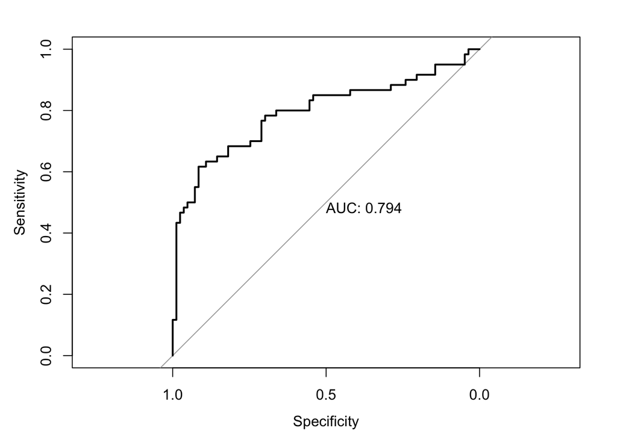

```r
roc.test = roc(test$Survived ~ prob1, plot = TRUE, print.auc = TRUE)
```

3. Explain your choices and communicate your results.

## Part 3: KNN (15 points)

1. Apply a KNN classification to the training data using.

```r
knn.train=cbind(train[,"PassengerId"], train[,"Sex"], train[,"Age"], train[,"SibSp"], train[,"Fare"], train[,"Embarked"])
knn.test=cbind(test[,"PassengerId"], test[,"Sex"], test[,"Age"], test[,"SibSp"], test[,"Fare"], test[,"Embarked"])
knn.trainLabels=train[,"Survived"]
knn.testLabels=test[,"Survived"]
```

2. Obtain the confusion matrix and compute the testing error rate based on the KNN classification.

```r
knn3 <- knn(train = knn.train, test = knn.test, cl = knn.trainLabels, k=3)
table(knn3, knn.testLabels)
```

```
##     knn.testLabels
## knn3  0  1
##    0 57 36
##    1 26 24
```

```r
1-mean(knn3==knn.testLabels)
```

```
## [1] 0.4335664
```

```r
knn5 <- knn(train = knn.train, test = knn.test, cl = knn.trainLabels, k=5)
table(knn5, knn.testLabels)
```

```
##     knn.testLabels
## knn5  0  1
##    0 64 37
##    1 19 23
```

```r
1-mean(knn5==knn.testLabels)
```

```
## [1] 0.3916084
```

```r
knn25=knn(knn.train,knn.test, cl = knn.trainLabels, k=25)
table(knn25, knn.testLabels)
```

```
##      knn.testLabels
## knn25  0  1
##     0 81 42
##     1  2 18
```

```r
1-mean(knn25==knn.testLabels)
```

```
## [1] 0.3076923
```

```r
set.seed(1234)
k.grid=1:100
error=rep(0, length(k.grid))

for (i in seq_along(k.grid)) {
  pred = knn(train = scale(knn.train),
             test  = scale(knn.test),
             cl    = knn.trainLabels,
             k     = k.grid[i])
  error[i] = mean(knn.testLabels !=pred)
}

min(error)
```

```
## [1] 0.2377622
```

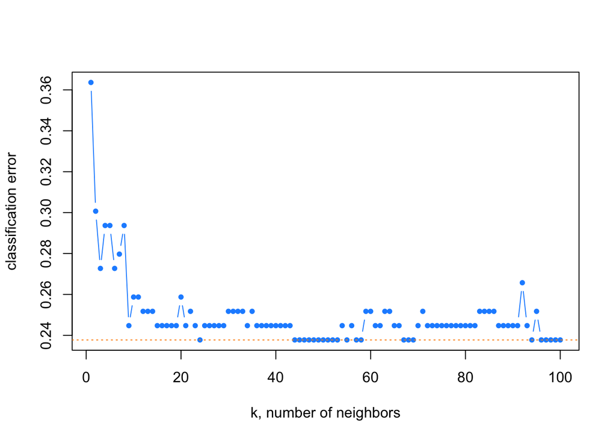

```r
plot(error, type = "b", col = "dodgerblue", cex = 1, pch = 20,
     xlab = "k, number of neighbors", ylab = "classification error")
# add line for min error seen
abline(h = min(error), col = "darkorange", lty = 3)
```

3. Explain your choices and communicate your results.

## Part 4: Tree Based Model (15 points)

1. Apply one of the following models to your training data: *Classification Tree, Random Forrest, Bagging or Boosting*

```r
titanic=read.table("/Users/aleena/Desktop/MSBA/DS805/project/Titanic-Dataset.csv", header = TRUE, sep=",", dec=".")
titanic=titanic[,-8]

titanic[titanic$Embarked == "","Embarked"] <- "S"
titanic=na.omit(titanic)

titanic$Pclass<-as.factor(titanic$Pclass)
titanic$Sex<-as.factor(titanic$Sex)
titanic$Embarked<-as.factor(titanic$Embarked)

set.seed(1)
n=round(nrow(titanic)*.8)
training=sample(nrow(titanic), n)
train=titanic[training,]
test=titanic[-training,]
```

Boosting

```r
set.seed(123)
model.boos <- gbm(formula = Survived ~ ., distribution="bernoulli", data=train, n.trees = 10000)
print(model.boos)
```

```
## gbm(formula = Survived ~ ., distribution = "bernoulli", data = train,
##     n.trees = 10000)
## A gradient boosted model with bernoulli loss function.
## 10000 iterations were performed.
## There were 8 predictors of which 8 had non-zero influence.
```

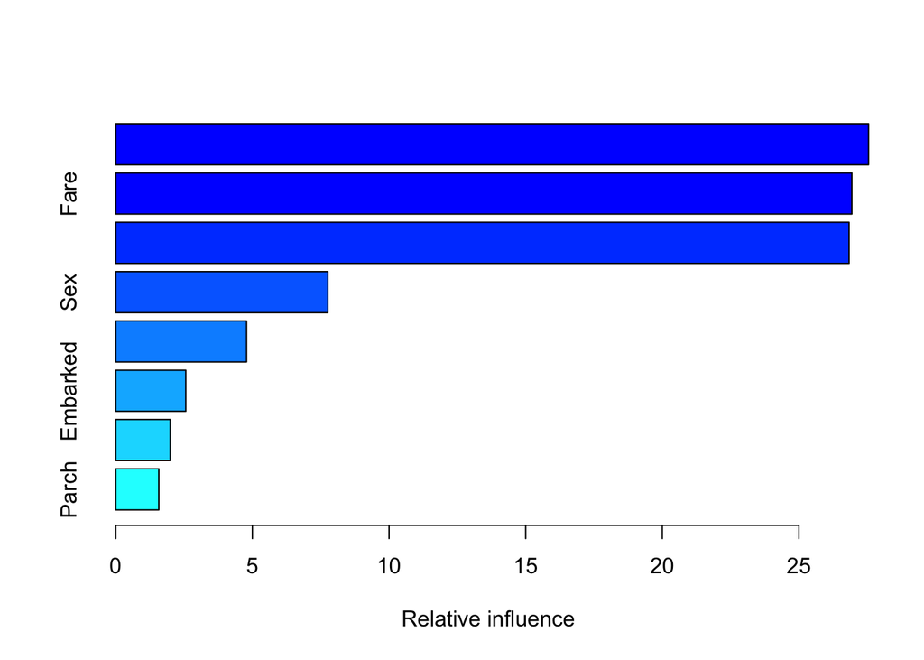

```
##                     var   rel.inf
## PassengerId PassengerId 27.548063
## Fare               Fare 26.936778
## Age                 Age 26.833804
## Sex                 Sex  7.761467
## Pclass           Pclass  4.786144
## Embarked       Embarked  2.563985
## SibSp             SibSp  1.993254
## Parch             Parch  1.576505
```

```r
summary(model.boos)
```

```r
#Obtaining Predictions and Computing the Test Error Rate
pred.boost=predict(model.boos, newdata=test,n.trees=10000, distribution="bernoulli", type="response")

boostpred=ifelse(pred.boost < 0.5, 0, 1)

#Prediction Accuracy
accuracy(test[,"Survived"], boostpred)
```

```
## [1] 0.7482517
```

```r
table(true=factor(boostpred),
      factor(test$Survived))
```

```
##
## true  0  1
##    0 72 25
##    1 11 35
```

```
## OOB generally underestimates the optimal number of iterations although predictive performance is reasonably competitive. Using cv_folds>1 when calling gbm usually results in improved predictive performance.
```

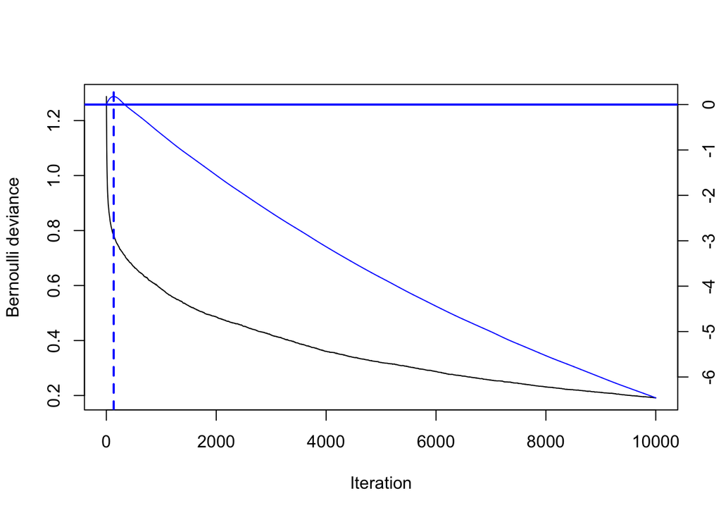

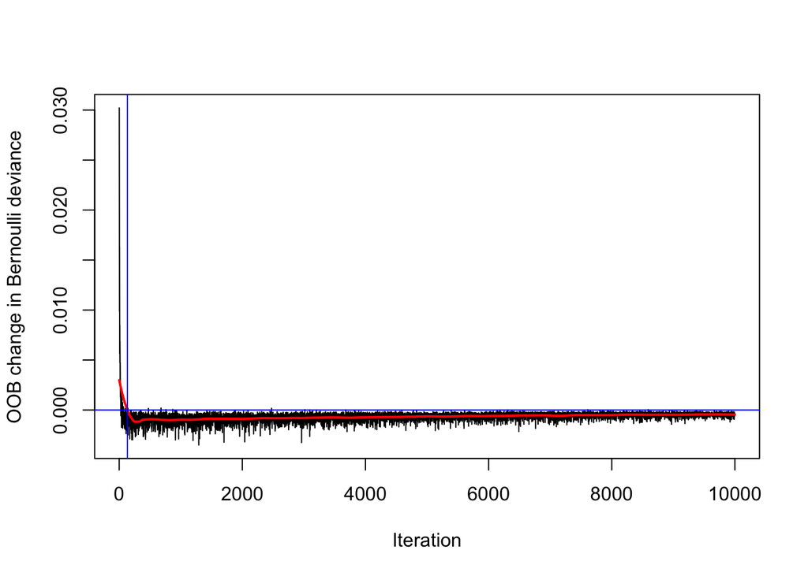

```r
# Using OOB
ntree.oob.opt=gbm.perf(model.boos, method="OOB", oobag.curve=TRUE)
```

```r
# Using CV
set.seed(123)
model.boos.cv <- gbm(Survived ~ .,
                       distribution = "bernoulli",
                       train,n.trees = 10000,
                       cv.folds = 3)
ntree.cv.opt=gbm.perf(model.boos.cv, method="cv")
```

[figure not shown]

```r
print(paste0("Optimal ntrees (OOB Estimate): ", ntree.oob.opt))
```

```
## [1] "Optimal ntrees (OOB Estimate): 133"
```

```r
#OOB is the better option in this case
print(paste0("Optimal ntrees (CV Estimate): ", ntree.cv.opt))
```

```
## [1] "Optimal ntrees (CV Estimate): 76"
```

```r
pred.oob=predict(object = model.boos,
                  newdata = test,
                  n.trees = ntree.oob.opt)
pred.cv=predict(object = model.boos.cv,
                  newdata = test,
                  n.trees = ntree.cv.opt)
auc1=auc(test$Survived, pred.oob)  #OOB
# Compare AUC (Area Under the Curve)
auc2=auc(test$Survived,pred.cv)  #CV

print(paste0("Test set AUC (OOB): ", round(auc1,3)))
```

```
## [1] "Test set AUC (OOB): 0.802"
```

```r
print(paste0("Test set AUC (CV): ", round(auc2,3)))
```

```
## [1] "Test set AUC (CV): 0.795"
```

```r
#If they are close then go with the model that is easiest to explain
```

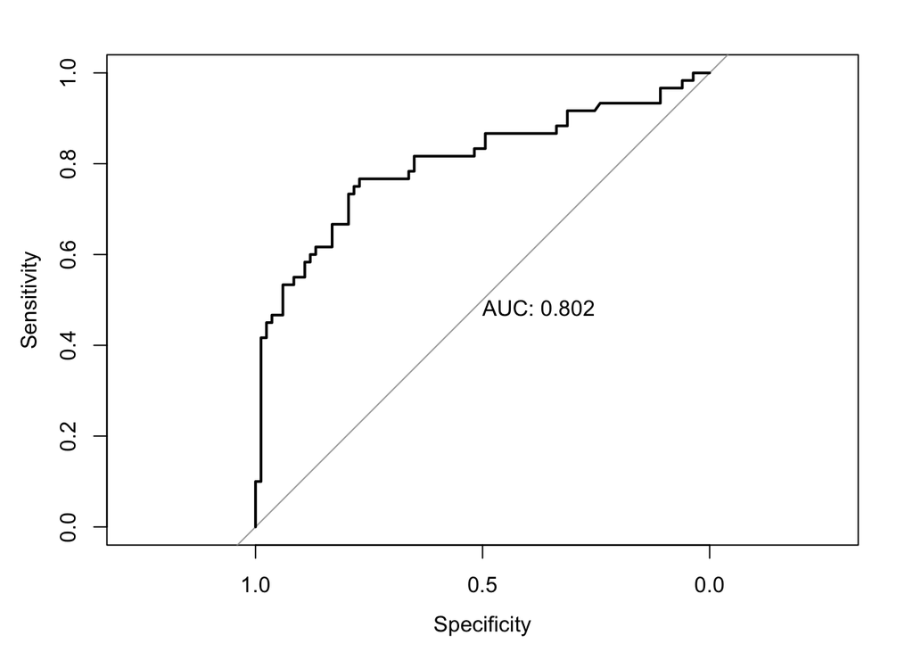

```r
roc.test = roc(test$Survived ~ pred.oob, plot = TRUE, print.auc = TRUE)
```

3. Explain your choices and communicate your results.

## Part 5: SVM (15 points)

1. Apply an SVM model to your training data.

```r
#build svm model, setting required parameters
svm_model<- svm(Survived ~ ., data = train, type = "C-classification", kernel = "linear", scale = FALSE, cost=0.1)
svm_model
```

```
##
## Call:
## svm(formula = Survived ~ ., data = train, type = "C-classification",
##     kernel = "linear", cost = 0.1, scale = FALSE)
##
##
## Parameters:
##    SVM-Type:  C-classification
##  SVM-Kernel:  linear
##        cost:  0.1
##
## Number of Support Vectors:  282
```

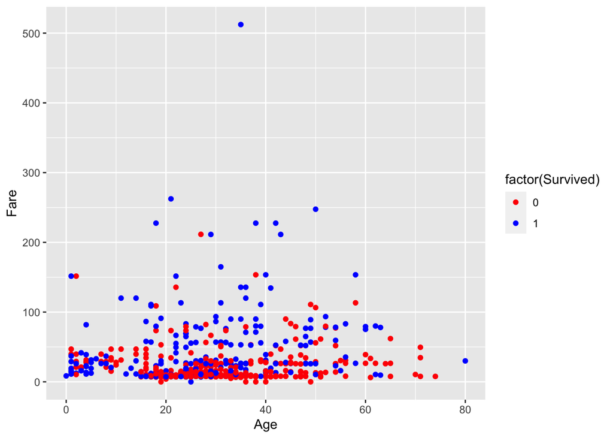

```r
titanic.df=subset(train, select = c(Survived, Age, Fare))
plot_margins <- ggplot(data = titanic.df, aes(x = Age, y = Fare, color = factor(Survived))) + geom_point() +
    scale_color_manual(values = c("red", "blue"))
#display plot
plot_margins
```

```r
svm_titanic<- svm(Survived ~ ., data = train, type = "C-classification", kernel = "linear", scale = TRUE)
svm_titanic
```

```
##
## Call:
## svm(formula = Survived ~ ., data = train, type = "C-classification",
##     kernel = "linear", scale = TRUE)
##
##
## Parameters:
##    SVM-Type:  C-classification
##  SVM-Kernel:  linear
##        cost:  1
##
## Number of Support Vectors:  270
```

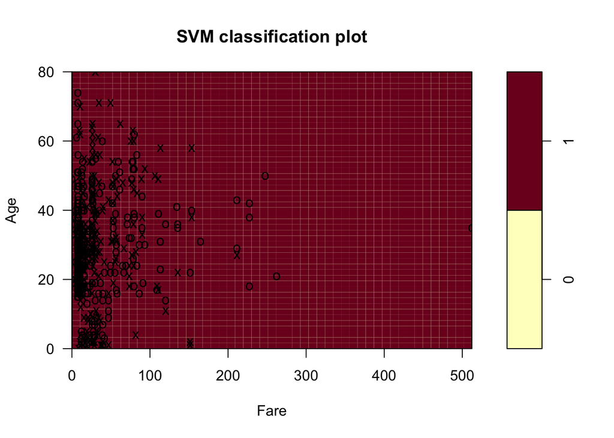

```r
plot(svm_titanic, train, Age~Fare)
```

```r
svm_radial<- svm(Survived ~ ., data = train, type = "C-classification", kernel = "radial", scale = TRUE)
pred_radial=predict(svm_radial,test)
mean(pred_radial==test$Survived)
```

```
## [1] 0.7552448
```

```r
set.seed (123)
tune.radial=tune(svm, factor(Survived)~., data=train,
                 kernel ="radial",
                 type = "C-classification",
                 ranges =list(cost=c(0.1,1,10,100),
                              gamma=c(0.5,1,2,3,4)))
```

```r
summary(tune.radial)
```

```
##
## Parameter tuning of 'svm':
##
## - sampling method: 10-fold cross validation
##
## - best parameters:
##  cost gamma
##     1   0.5
##
## - best performance: 0.1996975
##
## - Detailed performance results:
##     cost gamma     error dispersion
## 1    0.1   0.5 0.3219298 0.10196674
## 2    1.0   0.5 0.1996975 0.05815980
## 3   10.0   0.5 0.2258016 0.08323301
## 4  100.0   0.5 0.2626437 0.05514000
## 5    0.1   1.0 0.4025408 0.06878320
## 6    1.0   1.0 0.2171204 0.08011483
## 7   10.0   1.0 0.2486691 0.05999396
## 8  100.0   1.0 0.2714761 0.05511330
## 9    0.1   2.0 0.4025408 0.06878320
## 10   1.0   2.0 0.2782819 0.08799215
## 11  10.0   2.0 0.3133696 0.07112399
## 12 100.0   2.0 0.3098004 0.06745211
## 13   0.1   3.0 0.4025408 0.06878320
## 14   1.0   3.0 0.3132789 0.08248445
## 15  10.0   3.0 0.3412886 0.07436616
## 16 100.0   3.0 0.3202359 0.07850102
## 17   0.1   4.0 0.4025408 0.06878320
## 18   1.0   4.0 0.3097096 0.07480728
## 19  10.0   4.0 0.3307320 0.08359169
## 20 100.0   4.0 0.3447066 0.08824126
```

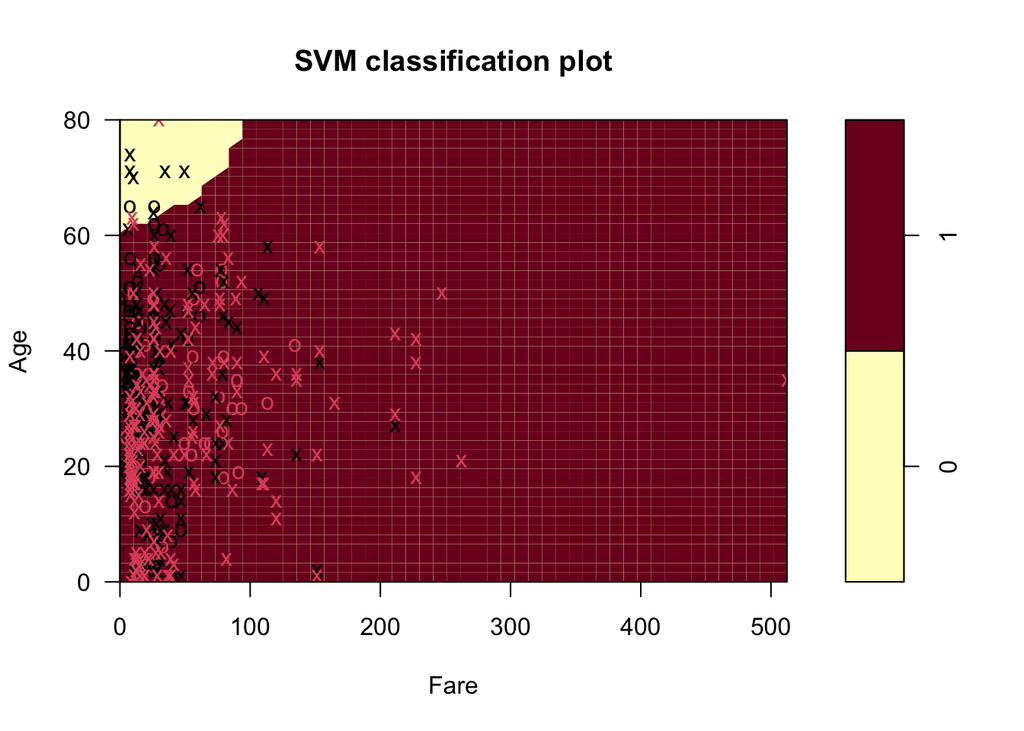

```r
bestmod=tune.radial$best.model
plot(bestmod, data=train, Age~Fare)
```

```r
#Original SVM w/ train data
table(true=train$Survived, pred=predict(svm_radial ,
newdata=train))
```

```
##     pred
## true   0   1
##    0 306  35
##    1  58 172
```

```r
#Tuned SVM w/ train data
#Use this model, true positive and true negative is better so it's more accurate
table(true=train$Survived, pred=predict(tune.radial$best.model ,
newdata=train))
```

```
##     pred
## true   0   1
##    0 321  20
##    1  41 189
```

2. Calculate the confusion matrix using the testing data.

```r
table(true=test$Survived,
      pred=predict(svm_radial,newdata=test))
```

```
##     pred
## true  0  1
##    0 69 14
##    1 21 39
```

```r
ce(test$Survived,
   predict(svm_radial,newdata=test))
```

```
## [1] 0.2447552
```

```r
#Best SVM model (Tuned) w/ test data
table(true=test$Survived,
      pred=predict(tune.radial$best.model,newdata=test))
```

```
##     pred
## true  0  1
##    0 72 11
##    1 21 39
```

```r
#Confusion Error
ce(test$Survived,predict(tune.radial$best.model
                       ,newdata=test))
```

```
## [1] 0.2237762
```

[figure not shown]

3. Explain your choices and communicate your results.

From plotting Survived against Age and Fare, we could tell from the scatter plot that the data was going to be difficult to split. The SVM Classification plot proved that by classifying all data points as a 1 and no 0’s. The mean prediction was 0.7552448 and when we tuned it the error rate was only 0.1996975 which is awesome. We then plotted the data on the Classification plot with the tuned data and were able to get slightly separated results. We then tested the accuracy of the tuned model with the confusion matrix and the tuned matrix had higher True Positive and Negative results, confirming that the tuning worked. The confusion matrix for the testing data showed similar results, so we know what this model is well-fit.

## Part 6: Conclusion (20 points)

1. (10 points) Based on the different classification models, which one do you think is the best model to predict `Survived`? Please consider the following in your response:
   - Accuracy/error rates

KNN: Accuracy = 69.23% Error Rate = 30.77%

Boosting: Accuracy = 74.82% Error Rate = 25.17%

```
- Do you think you can improve the model by adding any other information?
```

We think the model came out very well and don’t think there is any other information that could have helped us.

2. (10 points) What are your learning outcomes for this assignment? Please focus on your learning outcomes in terms of statistical learning, model interpretations, and R skills - it is up to you to include this part in your presentation or not.

We learned about the importance of knowing about the data set you are working with. We first went into writing the codes but we ran into errors so we had to go back and fix them. The easiest way to get information about our data set was to run Explanatory Data Analysis so that’s what we did. Errors were coming from class of variables or NA’s. We did a lot of factoring data and omitting NA’s to be able to run our analysis. In order to compare the different models, we tried to use the metrics when possible. We liked this assignment because it was a great way to sum up the different techniques we have learned this year. Obviously making predictions is a hard thing to do but we are confident that with this analysis we would be able to predict our dependent variable “Survived” with good accuracy.